# Shiny Manual: Dose-Response modeling

This Shiny App contains functions to perform a **dose-response modeling**, **exploration** and a **preliminary analysis** on the **dose-response relationship** of nanomaterial toxicity. Scatter plot can be generated for the data exploration and several inference methods for order restricted dose-response data are available in this app. Several nonlinear models are provided for the dose-response modeling of nanomaterial toxicity.

## 1. Upload Data

Data can be uploaded in the **Upload Data** menu, by clicking `BROWSE`. The uploaded data should be in a tab separated value format.

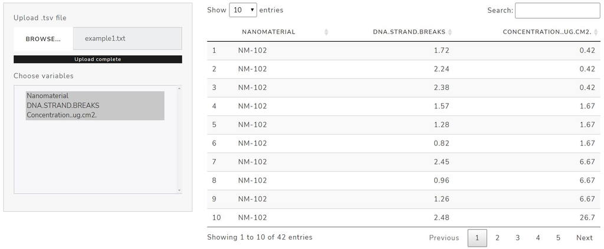

Figure 1: Upload data

To perform the dose-response analysis, the uploaded data should contain variable dose/concentration and response. This data should be a data of one nanomaterial and toxicity endpoint of interest. For the data exploration and preliminary analysis (scatter plot, isotonic plot and trend test), a variable indicating the name of nanomaterial should be available as well (for example, column `Nanomaterial` as seen in figure 1. The example 1 dataset presented in figure 1 can be downloaded in menu `DATA EXAMPLES`.

## 2. Plot and trend test

In menu **Plot and trend test**, we can generate plots of the dose and the response and perform inference to test the trend in the dose-response relationship of nanomaterial toxicity.  
To generate the plot or to perform the analysis, the name of the nanomaterial, the response of interest and and the concentration should be selected in the `Choose variable of nanomaterial name`, `Choose variable of response` and `Choose variable of dose` `/concentration` respectively. To generate the scatter plot of the dose and the response, as seen in figure 2, `Scatter plot` should be selected in `The result`.

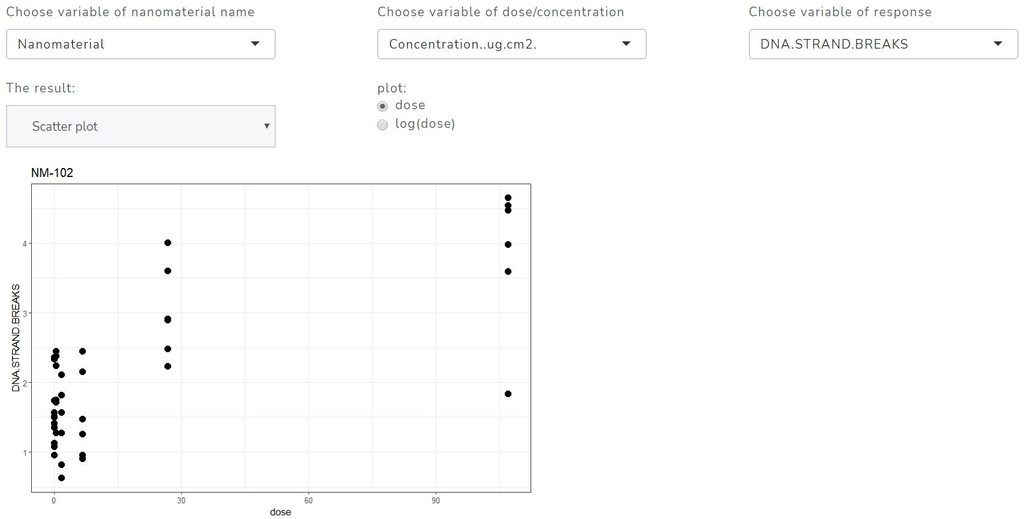

Figure 2: Scatter plot

Figure 3 shows the selections made to generate plot of the dose and the response, with isotonic means. By selecting `Isotonic means plot`, scatter plot with isotonic means will be generated.

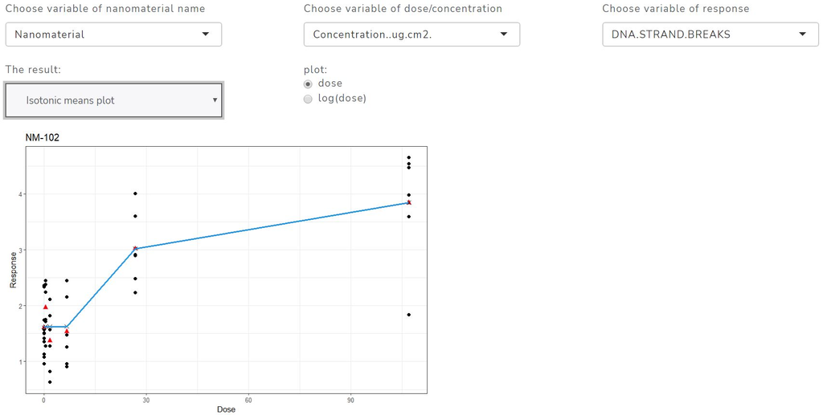

Figure 3: Plot with isotonic means

Figure 4 shows the steps to perform the inference. The method, the seed and the number of permutations can be specified in `Choose the test statistics`, `Specify seed:` and `Number of permutations:`, respectively.

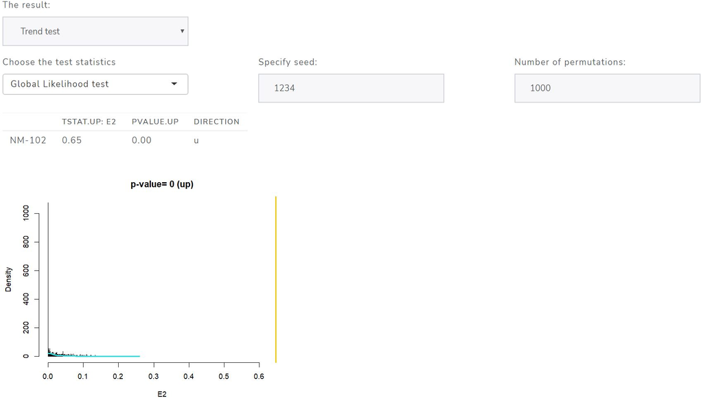

Figure 4: Trend test

## 2. Dose-response model

Menu **Dose-response model** provides option to generate model fitting on the dose-response relationship of nanomaterial toxicity. Several non-linear models are available, such as 3, 4 and 5 parameter log-logistic regression model, Weibull model and Gompertz model. One or more models can be chosen in the option `Select model`. Variable of the dose can be selected in the option `Choose variable of dose/concentration` and variable response can be selected in the `Choose variable of response`. The level of the response (or the ED) can be specified in `Specify ED level`, while the level of the confidence interval can be specified in `The level for the confidence interval`.  
As seen in figure 5, ED50 is to be estimated. ED50 estimated here is the dose that is associated with a halfway reduction between the lower and the upper limits of the dose-response curve as doses approach infinity and 0, respectively.

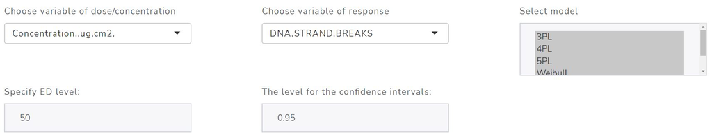

Figure 5: Model fitting

Figure 6 shows the result of the model fitting. It consists of three part: `Result (all models):` containing the fitting result of the all specified models, `Result (inside dose range):` for the result of the model of which its estimate of effective dose lies between the dose range in the data and `Average ED` containing the estimate of the effective dose that is calculated by the model averaging.

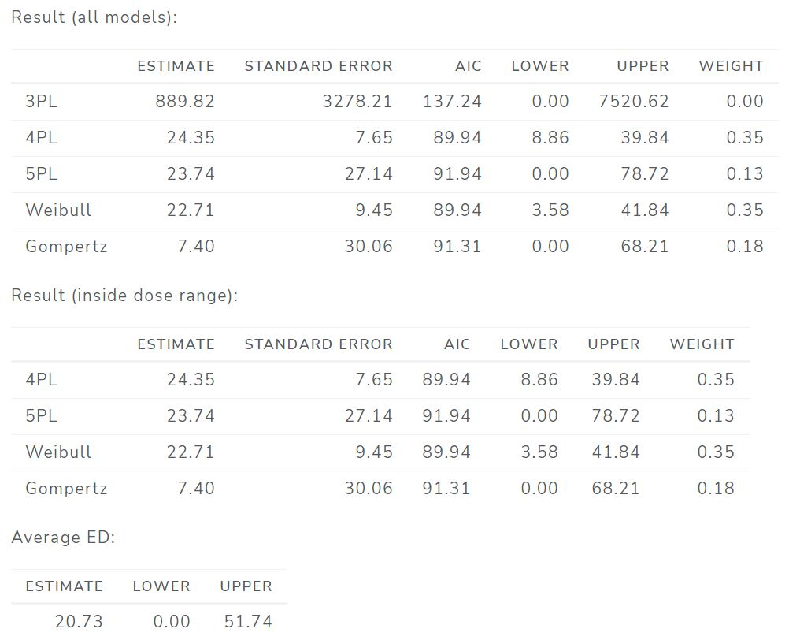

Figure 6: Result of the model fitting

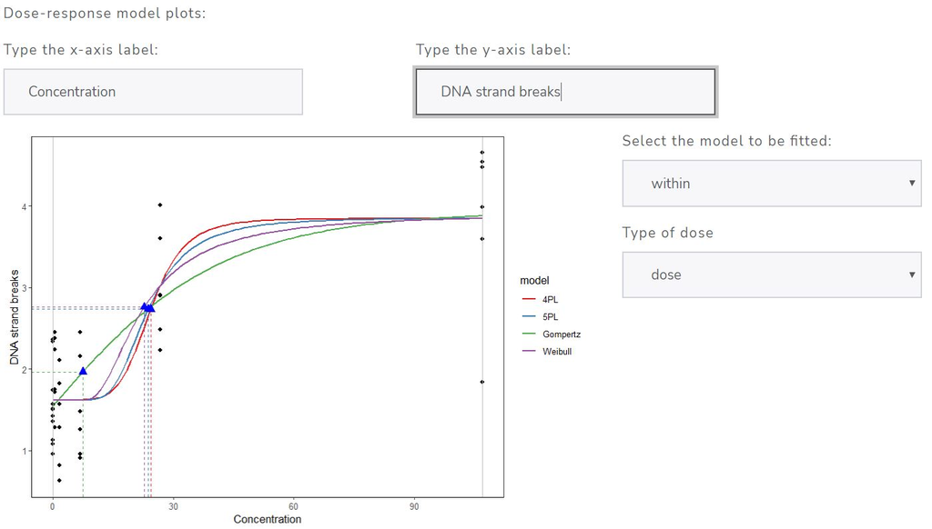

Figure 7: Dose-response model plot

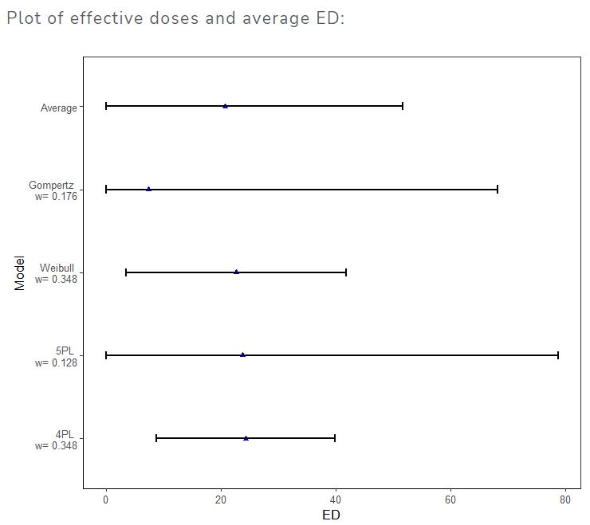

Figure 8: Effective doses plot